# 2019 OmegaQuant Plot v1.3

Benny Rice

03/26/2019

#### Notes

- Data types to visualize and/or analyze in this file:
1. OmegaQuant fatty acid results (using a sample of data from the CRS2017 project and the Kiribati 2020 project)

#### Defining thresholds

- See **[GitHub](https://github.com/bennyrice/OmegaQuant)** for associated documentation on cut-offs (i.e., Harris et al 2017)

##### Omega-3 index

```r
# Omega-3 index values >  6.1%            = no increased cardiovascular health risk
# Omega-3 index values <= 6.1% and > 4.0% = increased cardiovascular health risk
# Omega-3 index values <= 4.0%            = greatly increased cardiovascular health risk
```

##### Trans fat index

**Note:** Trans fat index seems to be missing from the Kiribati data

```r
# Trans fat index values <  1.00%             = no increased cardiovascular health risk
# Trans fat index values >= 1.00% and < 1.75% = intermediate cardiovascular health risk
# Trans fat index values >= 1.75%             = increased cardiovascular health risk
```

Set up: Defining main working directory

Set up: Loading packages (*not all may be necessary)

Set up: Reading in CSVs

- Excel sheets `MAHERY Results 01252019.xlsx` and `OmegaQuant Results - Harvard - Golden - P378-US1 - DBS - 16Jul2020.xlsx` manually saved as CSV files
- Subsequent analysis may need to link to age and sex data (not done here)

# (1) Fatty Acid Data

#### (1.1) Applying Omega 3 thresholds:

(1.1.1) Specifying Omega 3 outcomes

```r
# Omega-3 index values >  6.1%            = no increased cardiovascular health risk
# Omega-3 index values <= 6.1% and > 4.0% = increased cardiovascular health risk
# Omega-3 index values <= 4.0%            = greatly increased cardiovascular health risk

# (OM3_1) Omega.3.Index >  6.1                       ~ '1_no_increased_risk'
# (OM3_2) Omega.3.Index <= 6.1 & Omega.3.Index > 4.0 ~ '2_increased_risk'
# (OM3_3) Omega.3.Index <= 4.0                       ~ '3_greatly_increased_risk'
```

(1.1.2) Filtering Omega 3 data per thresholds

Preview of cleaned and filtered Omega 3 data:

CRS: Preview of cleaned and filtered Omega 3 data

| OmQ_filter_paper_id | region_name | village_name | Omega.3.Index | Trans.Fat.Index | OM3_outcome_cat |
| --- | --- | --- | --- | --- | --- |
| 2.4.258 | r2_Mananjary | 4_Ambalavontanka | 4.20 | 0.42 | 2_increased_risk |
| 2.4.273 | r2_Mananjary | 4_Ambalavontanka | 5.48 | 0.54 | 2_increased_risk |
| 2.4.257 | r2_Mananjary | 4_Ambalavontanka | 5.37 | 0.45 | 2_increased_risk |
| 2.4.267 | r2_Mananjary | 4_Ambalavontanka | 4.26 | 0.42 | 2_increased_risk |
| 2.4.266 | r2_Mananjary | 4_Ambalavontanka | 4.04 | 0.49 | 2_increased_risk |
| 2.4.252 | r2_Mananjary | 4_Ambalavontanka | 4.24 | 0.47 | 2_increased_risk |
| 2.4.250 | r2_Mananjary | 4_Ambalavontanka | 5.05 | 0.44 | 2_increased_risk |
| 2.1.110 | 2_Mananjary | 1_Tsaravary | 5.90 | 0.46 | 2_increased_risk |
| 2.1.109 | 2_Mananjary | 1_Tsaravary | 3.71 | 0.39 | 3_greatly_increased_risk |
| 2.1.114 | 2_Mananjary | 1_Tsaravary | 4.72 | 0.53 | 2_increased_risk |
| 2.1.117 | 2_Mananjary | 1_Tsaravary | 3.85 | 0.41 | 3_greatly_increased_risk |
| 2.1.107 | 2_Mananjary | 1_Tsaravary | 4.14 | 0.37 | 2_increased_risk |
| 2.1.132 | 2_Mananjary | 1_Tsaravary | 4.54 | 0.64 | 2_increased_risk |
| 2.1.121 | 2_Mananjary | 1_Tsaravary | 4.53 | 0.43 | 2_increased_risk |
| 2.1.124 | 2_Mananjary | 1_Tsaravary | 5.09 | 0.47 | 2_increased_risk |
| 2.1.120 | 2_Mananjary | 1_Tsaravary | 6.80 | 0.48 | 1_no_increased_risk |
| 2.1.130 | 2_Mananjary | 1_Tsaravary | 5.33 | 0.42 | 2_increased_risk |
| 2.1.127 | 2_Mananjary | 1_Tsaravary | 4.60 | 0.45 | 2_increased_risk |
| 2.1.137 | 2_Mananjary | 1_Tsaravary | 4.55 | 0.47 | 2_increased_risk |
| 2.1.149 | 2_Mananjary | 1_Tsaravary | 6.35 | 0.46 | 1_no_increased_risk |
| 2.1.160 | 2_Mananjary | 1_Tsaravary | 5.38 | 0.39 | 2_increased_risk |
| 2.1.035 | 2_Mananjary | 1_Tsaravary | 4.63 | 0.49 | 2_increased_risk |
| 2.1.032 | 2_Mananjary | 1_Tsaravary | 3.38 | 0.57 | 3_greatly_increased_risk |
| 2.1.029 | 2_Mananjary | 1_Tsaravary | 6.24 | 0.49 | 1_no_increased_risk |
| 2.1.027 | 2_Mananjary | 1_Tsaravary | 4.42 | 0.51 | 2_increased_risk |
| 2.1.026 | 2_Mananjary | 1_Tsaravary | 5.00 | 0.53 | 2_increased_risk |
| 2.1.025 | 2_Mananjary | 1_Tsaravary | 6.45 | 0.53 | 1_no_increased_risk |
| 2.1.022 | 2_Mananjary | 1_Tsaravary | 5.17 | 0.58 | 2_increased_risk |
| 2.1.021 | 2_Mananjary | 1_Tsaravary | 5.35 | 0.56 | 2_increased_risk |
| 2.1.009 | 2_Mananjary | 1_Tsaravary | 4.70 | 0.31 | 2_increased_risk |

[output cut: 70 more lines]

KIRI: Preview of cleaned and filtered Omega 3 data

| Info.on.Collection.Card | Date | Location | Omega.3.Index | OM3_outcome_cat |
| --- | --- | --- | --- | --- |
| 1304_4185_2 | Round 23 | Buota Tab North | 9.59 | 1_no_increased_risk |
| 1304_4185_3 | Round 23 | Buota Tab North | 9.95 | 1_no_increased_risk |
| 1304_4185_1 | Round 23 | Buota Tab North | 8.80 | 1_no_increased_risk |
| 1304_4194_1 | Round 23 | Buota Tab North | 7.52 | 1_no_increased_risk |
| 1304_4194_2 | Round 23 | Buota Tab North | 10.78 | 1_no_increased_risk |
| 1307_4262_2 | Round 23 | Buota Tab North | 10.82 | 1_no_increased_risk |
| 1307_4262_1 | Round 23 | Buota Tab North | 11.30 | 1_no_increased_risk |
| 1307_4265_1 | Round 23 | Buota Tab North | 8.96 | 1_no_increased_risk |
| 1307_4265_2 | Round 23 | Buota Tab North | 9.61 | 1_no_increased_risk |
| 1307_4263_1 | Round 23 | Buota Tab North | 7.37 | 1_no_increased_risk |
| 1307_4261_2 | Round 23 | Buota Tab North | 11.34 | 1_no_increased_risk |
| 1307_4261_1 | Round 23 | Buota Tab North | 9.33 | 1_no_increased_risk |
| 1307_4260_3 | Round 23 | Buota Tab North | 9.55 | 1_no_increased_risk |
| 1307_4260_2 | Round 23 | Buota Tab North | 9.05 | 1_no_increased_risk |
| 1307_4260_1 | Round 23 | Buota Tab North | 7.51 | 1_no_increased_risk |
| 1307_4259_1 | Round 23 | Buota Tab North | 7.29 | 1_no_increased_risk |
| 1307_4266_1 | Round 23 | Buota Tab North | 6.44 | 1_no_increased_risk |
| 1307_4269_2 | Round 23 | Buota Tab North | 9.65 | 1_no_increased_risk |
| 1307_4269_3 | Round 23 | Buota Tab North | 8.40 | 1_no_increased_risk |
| 1307_4256_3 | Round 23 | Buota Tab North | 9.09 | 1_no_increased_risk |
| 1307_4256_2 | Round 23 | Buota Tab North | 8.62 | 1_no_increased_risk |
| 1307_4256_1 | Round 23 | Buota Tab North | 10.45 | 1_no_increased_risk |
| 1307_4265_3 | Round 23 | Buota Tab North | 10.09 | 1_no_increased_risk |
| 1307_4245_4 | Round 23 | Buota Tab North | 8.88 | 1_no_increased_risk |
| 1307_4243_2 | Round 23 | Buota Tab North | 6.44 | 1_no_increased_risk |
| 1307_4247_1 | Round 23 | Buota Tab North | 9.47 | 1_no_increased_risk |
| 1307_4247_3 | Round 23 | Buota Tab North | 9.78 | 1_no_increased_risk |
| 1307_4243_1 | Round 23 | Buota Tab North | 8.53 | 1_no_increased_risk |
| 1307_4247_2 | Round 23 | Buota Tab North | 10.43 | 1_no_increased_risk |
| 1307_4241_1 | Round 23 | Buota Tab North | 10.71 | 1_no_increased_risk |

[output cut: 70 more lines]

- (even here you can already see a difference between Madagascar and Kiribati)

#### (2.1) Applying Trans fat thresholds:

- (**NOTE:** No trans data available for Kiribati in the date file)

(2.1.1) Specifying Trans fat outcomes

```r
# Trans fat index values <  1.00%             = no increased cardiovascular health risk
# Trans fat index values >= 1.00% and < 1.75% = intermediate cardiovascular health risk
# Trans fat index values >= 1.75%             = increased cardiovascular health risk

# (TFAT_1) Trans.Fat.Index <  1.00                          ~ '1_no_increased_risk'
# (TFAT_2) Trans.Fat.Index >= 1.00 & Trans.Fat.Index < 1.75 ~ '2_increased_risk'
# (TFAT_3) Trans.Fat.Index >= 1.75                          ~ '3_greatly_increased_risk'
```

(2.1.2) Filtering Trans fat data per thresholds

Preview of cleaned and filtered Trans fat data:

CRS: Preview of cleaned and filtered Trans fat data

| OmQ_filter_paper_id | region_name | village_name | Omega.3.Index | Trans.Fat.Index | OM3_outcome_cat | TFAT_outcome_cat |
| --- | --- | --- | --- | --- | --- | --- |
| 2.4.258 | r2_Mananjary | 4_Ambalavontanka | 4.20 | 0.42 | 2_increased_risk | 1_no_increased_risk |
| 2.4.273 | r2_Mananjary | 4_Ambalavontanka | 5.48 | 0.54 | 2_increased_risk | 1_no_increased_risk |
| 2.4.257 | r2_Mananjary | 4_Ambalavontanka | 5.37 | 0.45 | 2_increased_risk | 1_no_increased_risk |
| 2.4.267 | r2_Mananjary | 4_Ambalavontanka | 4.26 | 0.42 | 2_increased_risk | 1_no_increased_risk |
| 2.4.266 | r2_Mananjary | 4_Ambalavontanka | 4.04 | 0.49 | 2_increased_risk | 1_no_increased_risk |
| 2.4.252 | r2_Mananjary | 4_Ambalavontanka | 4.24 | 0.47 | 2_increased_risk | 1_no_increased_risk |
| 2.4.250 | r2_Mananjary | 4_Ambalavontanka | 5.05 | 0.44 | 2_increased_risk | 1_no_increased_risk |
| 2.1.110 | 2_Mananjary | 1_Tsaravary | 5.90 | 0.46 | 2_increased_risk | 1_no_increased_risk |
| 2.1.109 | 2_Mananjary | 1_Tsaravary | 3.71 | 0.39 | 3_greatly_increased_risk | 1_no_increased_risk |
| 2.1.114 | 2_Mananjary | 1_Tsaravary | 4.72 | 0.53 | 2_increased_risk | 1_no_increased_risk |
| 2.1.117 | 2_Mananjary | 1_Tsaravary | 3.85 | 0.41 | 3_greatly_increased_risk | 1_no_increased_risk |
| 2.1.107 | 2_Mananjary | 1_Tsaravary | 4.14 | 0.37 | 2_increased_risk | 1_no_increased_risk |
| 2.1.132 | 2_Mananjary | 1_Tsaravary | 4.54 | 0.64 | 2_increased_risk | 1_no_increased_risk |
| 2.1.121 | 2_Mananjary | 1_Tsaravary | 4.53 | 0.43 | 2_increased_risk | 1_no_increased_risk |
| 2.1.124 | 2_Mananjary | 1_Tsaravary | 5.09 | 0.47 | 2_increased_risk | 1_no_increased_risk |
| 2.1.120 | 2_Mananjary | 1_Tsaravary | 6.80 | 0.48 | 1_no_increased_risk | 1_no_increased_risk |
| 2.1.130 | 2_Mananjary | 1_Tsaravary | 5.33 | 0.42 | 2_increased_risk | 1_no_increased_risk |
| 2.1.127 | 2_Mananjary | 1_Tsaravary | 4.60 | 0.45 | 2_increased_risk | 1_no_increased_risk |
| 2.1.137 | 2_Mananjary | 1_Tsaravary | 4.55 | 0.47 | 2_increased_risk | 1_no_increased_risk |
| 2.1.149 | 2_Mananjary | 1_Tsaravary | 6.35 | 0.46 | 1_no_increased_risk | 1_no_increased_risk |
| 2.1.160 | 2_Mananjary | 1_Tsaravary | 5.38 | 0.39 | 2_increased_risk | 1_no_increased_risk |
| 2.1.035 | 2_Mananjary | 1_Tsaravary | 4.63 | 0.49 | 2_increased_risk | 1_no_increased_risk |
| 2.1.032 | 2_Mananjary | 1_Tsaravary | 3.38 | 0.57 | 3_greatly_increased_risk | 1_no_increased_risk |
| 2.1.029 | 2_Mananjary | 1_Tsaravary | 6.24 | 0.49 | 1_no_increased_risk | 1_no_increased_risk |
| 2.1.027 | 2_Mananjary | 1_Tsaravary | 4.42 | 0.51 | 2_increased_risk | 1_no_increased_risk |
| 2.1.026 | 2_Mananjary | 1_Tsaravary | 5.00 | 0.53 | 2_increased_risk | 1_no_increased_risk |
| 2.1.025 | 2_Mananjary | 1_Tsaravary | 6.45 | 0.53 | 1_no_increased_risk | 1_no_increased_risk |
| 2.1.022 | 2_Mananjary | 1_Tsaravary | 5.17 | 0.58 | 2_increased_risk | 1_no_increased_risk |
| 2.1.021 | 2_Mananjary | 1_Tsaravary | 5.35 | 0.56 | 2_increased_risk | 1_no_increased_risk |
| 2.1.009 | 2_Mananjary | 1_Tsaravary | 4.70 | 0.31 | 2_increased_risk | 1_no_increased_risk |

[output cut: 70 more lines]

#### (2.3) Visualizing Omega 3 and Trans fat data

(2.3.1) MADAGASCAR (CRS): Proportions of the sample population with a given Omega 3 level

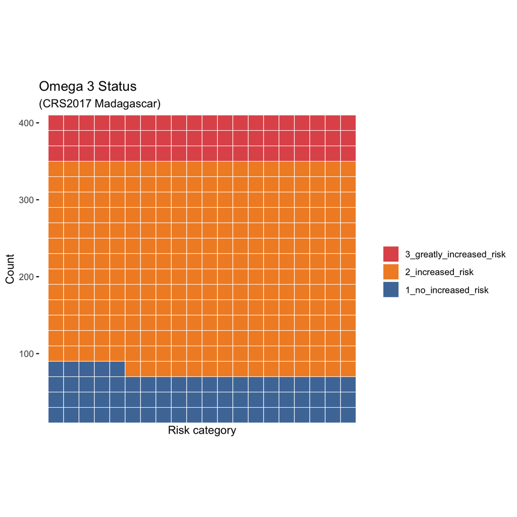

(2.3.2) KIRIBATI: Proportions of the sample population with a given Omega 3 level

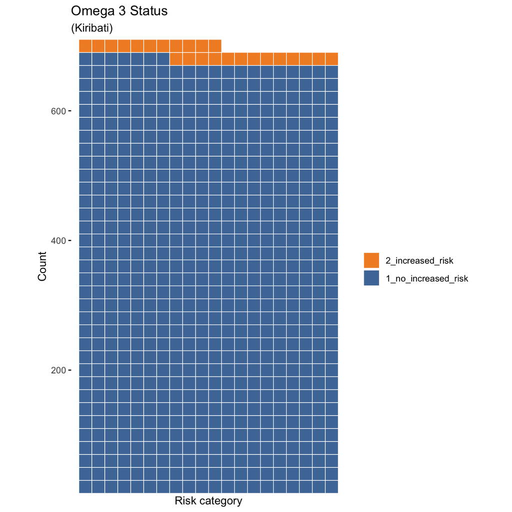

(2.3.3) MADAGASCAR (CRS): Proportions of the sample population with a given Trans fat level

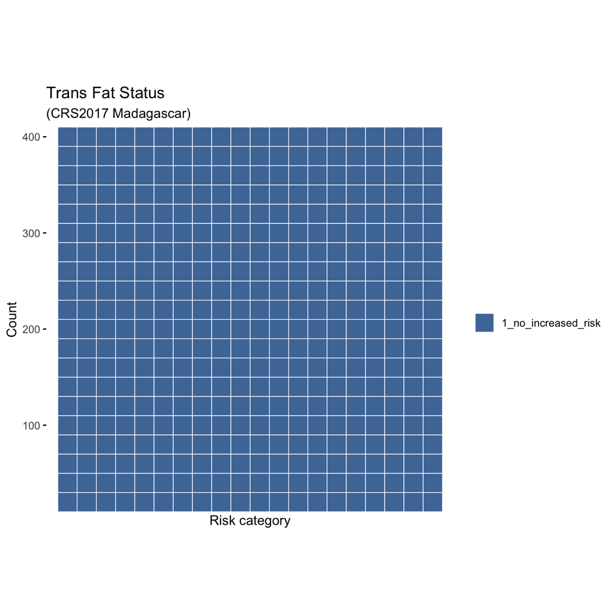

(2.3.4) **MADAGASCAR (CRS2017)**: Scatter plot of Omega 3 Levels

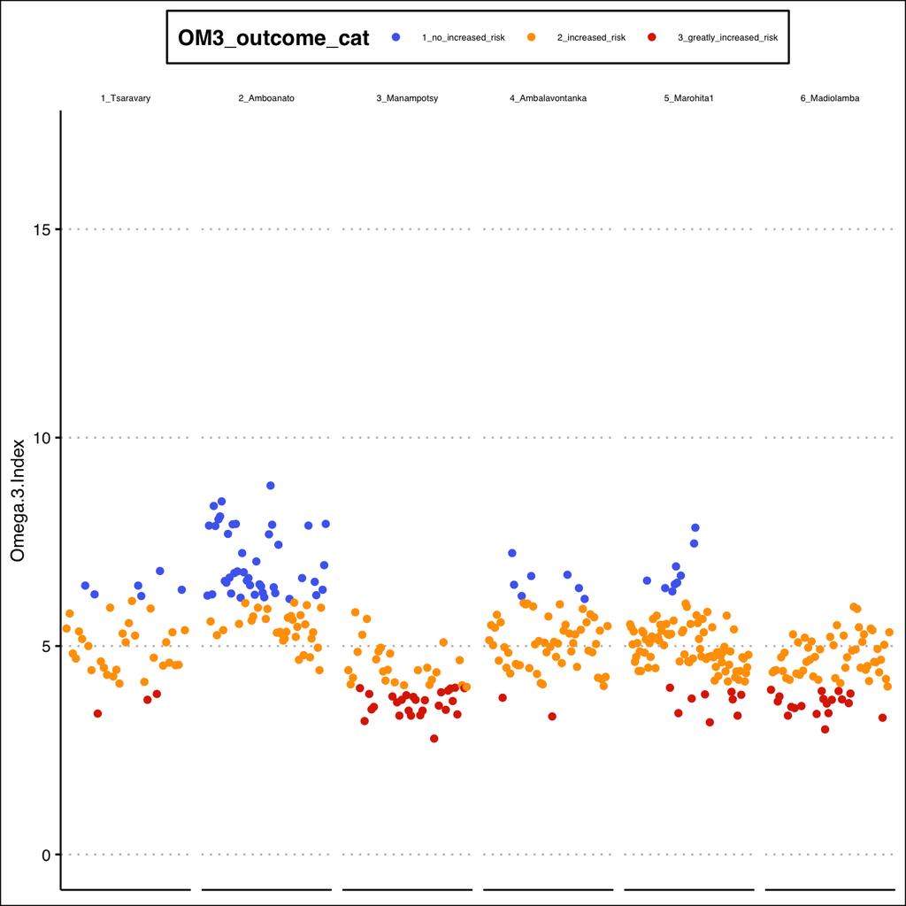

(2.3.5) **KIRIBATI**: Scatter plot of Omega 3 Levels

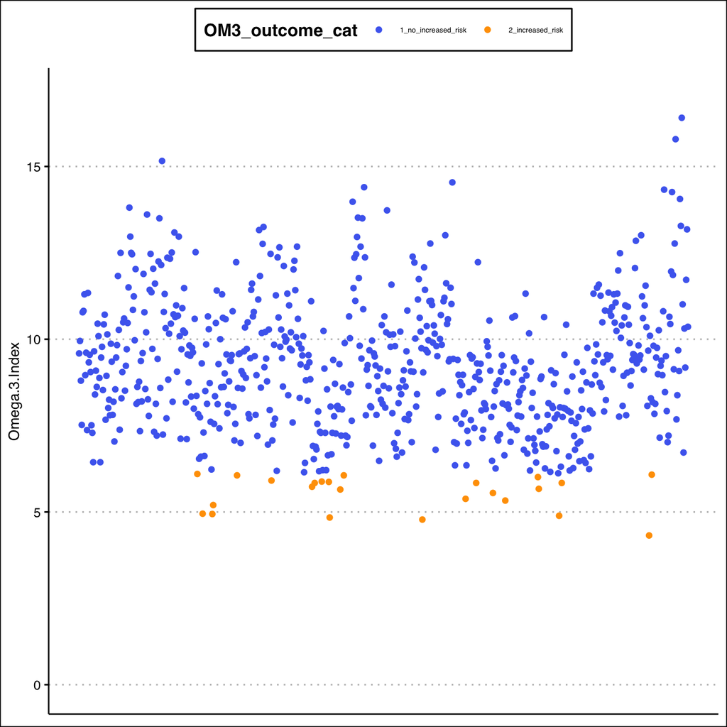